# SharkNinja Impact Analysis

AHT

Balto Data Science - 08 November 2021

# Approach

1. Estimate a statistical (mixed) model that is a function of the agent, their average usage of Balto, it’s square, and time.
2. Calculate a 95% confidence interval around the estimated effect for Balto use, then translate the estimates to a percentage deviation from the sample average.
3. Visualize the estimated effect.

We find a statistically significant negative impact for daily average checklist use on agent daily AHT.

# Results

## Summary Table

| Estimated Balto effect | P-value | 95% CI Lower bound | 95% CI Upper bound |
| --- | --- | --- | --- |
| -2% | 0.004 | -3% | -1% |

## Visualization

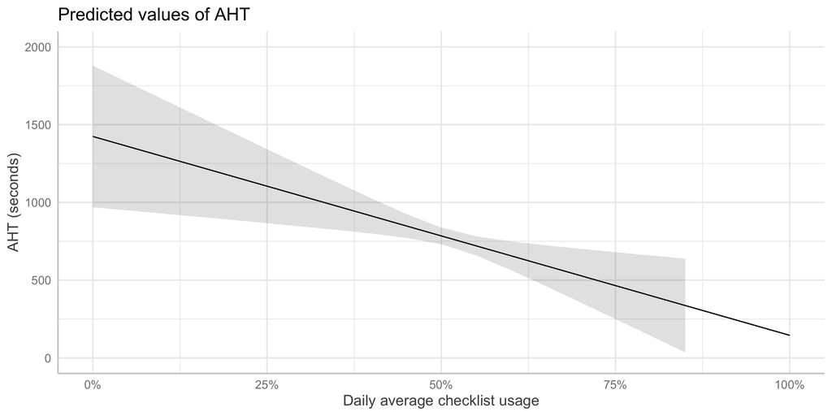

## Technical Details

### Model Output

aht

Predictors

Estimates

95% CI

P-value

Intercept

1423.99 ***

968.49 – 1879.49

**<0.001**

Average Checklist Usage

-12.79 **

-21.60 – -3.98

**0.004**

Average Checklist Usage  
Squared

302.59 ***

188.05 – 417.13

**<0.001**

Linear Time Trend

-47.58 ***

-68.97 – -26.19

**<0.001**

Random Effects

σ<sup>2</sup>

65733.19

τ<sub>00</sub> <sub>user_id</sub>

52523.20

ICC

0.44

N <sub>user_id</sub>

92

Observations

599

Marginal R<sup>2</sup> / Conditional R<sup>2</sup>

0.165 / 0.536

- p<0.05 ** p<0.01 *** p<0.001

### Data

|  | user_id | aht | cid | date | mean_use_all | call_count | Agent | mean_use_first | time_trend | mean_use_all_sq |
| --- | --- | --- | --- | --- | --- | --- | --- | --- | --- | --- |
| 0 | 14479 | 561.560776115385 | cb671831-8881-4d1f-ba18-8455d98cdeb6 | 2021-10-25 | 42.3076923076923 | 26 | NICOLE CLARKE | 19.2307692307692 | 18925 | 1789.94082840237 |
| 1 | 14480 | 511.925255965517 | cb671831-8881-4d1f-ba18-8455d98cdeb6 | 2021-10-25 | 55.5555555555556 | 29 | NICOLE HEATH | 44.8275862068966 | 18925 | 3086.41975308642 |
| 2 | 14481 | 826.645897277778 | cb671831-8881-4d1f-ba18-8455d98cdeb6 | 2021-10-25 | 61.1111111111111 | 18 | PASHAE BOGLE | 72.2222222222222 | 18925 | 3734.56790123457 |
| 3 | 14494 | 719.831731 | cb671831-8881-4d1f-ba18-8455d98cdeb6 | 2021-10-25 | 42.5925925925926 | 18 | CECIL WALSH | 27.7777777777778 | 18925 | 1814.12894375857 |
| 4 | 15439 | 513.368089928572 | cb671831-8881-4d1f-ba18-8455d98cdeb6 | 2021-10-25 | 49.2063492063492 | 14 | DEVAUN GREENSWORD | 42.8571428571429 | 18925 | 2421.26480221718 |
| 5 | 15736 | 114.36969 | cb671831-8881-4d1f-ba18-8455d98cdeb6 | 2021-10-25 | 44.4444444444444 | 1 | ALICIA MORGAN | 0 | 18925 | 1975.30864197531 |
| 6 | 15745 | 725.624034588235 | cb671831-8881-4d1f-ba18-8455d98cdeb6 | 2021-10-25 | 62.7450980392157 | 17 | PETAGAY WHYTE | 52.9411764705882 | 18925 | 3936.94732795079 |
| 7 | 17148 | 461.4779644 | cb671831-8881-4d1f-ba18-8455d98cdeb6 | 2021-10-25 | 66.6666666666667 | 5 | ANNETA ROBINSON | 60 | 18925 | 4444.44444444444 |
| 8 | 17150 | 786.0504525 | cb671831-8881-4d1f-ba18-8455d98cdeb6 | 2021-10-25 | 46.1111111111111 | 20 | DANENIA GRIFFITHS | 0 | 18925 | 2126.23456790123 |
| 9 | 17160 | 624.358649827586 | cb671831-8881-4d1f-ba18-8455d98cdeb6 | 2021-10-25 | 44.4444444444444 | 29 | TIASHA GRIFFITHS | 0 | 18925 | 1975.30864197531 |

[output cut: 589 more lines]

Balto.ai